# Data manipulation with `dplyr`

Data Science for Biologists, Spring 2020

Poonam Shah

## Instructions

**This assignment must be submitted as an RMarkdown document on Blackboard by *Thursday February 19th at 10:00 am*.**

#### You will be graded on the following criteria:

- Did you enter your name appropriately into the YAML front matter?
- Does the document knit without errors? *Adding `eval=FALSE` to code chunks with errors will not avoid penalty.*
- Does your code in the R chunks have appropriate *comments*?
- Is your submission appropriately *professional*?
  - *You need to run SPELL CHECK before submitting*, available under `Edit->Check Spelling`.
- Do all figures have clean axis labels? (Titles are optional). There should NOT be any underscores in axis labels.
- Did you write your written answers in the answer style?
- Have you addressed the questions as they are asked? Be sure to limit your code and your answers to the scope of the question!
  - If you write code that is not ultimately part of your final answer, you must either: delete it, comment it out, OR move it to a different R chunk with the added chunk options `eval=FALSE, echo=FALSE`.
- Is all work your own, including code and written answers?
  - If ANY of your submitted work is not your own (with the exception of what you have been provided), you will receive a 0 on the assignment. You will be reported for a Level 2 or 3 Academic Integrity Violation, depending on the severity of the issue.

## Resources

Your resources for working with `dplyr` include:

1. [dplyr documentation](http://rmarkdown.rstudio.com)
2. [dplyr Cheatsheet](https://github.com/rstudio/cheatsheets/blob/master/data-transformation.pdf)
3. [The dplyr Vignette](https://dplyr.tidyverse.org/articles/dplyr.html)

> NOTE: *Many* packages in R have a function called `select()` including base R, so it is not unusual for R to get confused which `select()` you are trying to use (later on we will learn where this confusion comes from). If you ever see an error that `select()` isn’t working as you expect, re-write it explicitly as `dplyr::select()` to clearly tell R that you want the `dplyr` function.

> NOTE2: The library `tidylog` is actually *modifying* `dplyr` functions so that they also print out various informative messages. Therefore, if you specify `dplyr::<function>` these messages will NOT appear because the `dplyr` versions will be used. If you specify `tidylog::<function>` you can ensure messages DO appear. Because we loaded `tidylog` AFTER `tidyverse`, the default versions R assumes you want to use are `tidylog`’s functions if you do not explicitly specify.

## Setup

We will learn the fundamentals of `dplyr` using the built-in R dataset `CO2`. This dataset is not in the best default format, so we will define it as a tibble for our use, **but save it as a new variable `CO2_tibble`**.

```r
# Create a new lowercase variable. __NEVER__ overwrite base R variables.
# CO2 <- as.tibble(CO2) is _very bad._ Don't do this.
CO2_tibble <- as_tibble(CO2)
head(CO2_tibble)
```

```
## # A tibble: 6 x 5
##   Plant Type   Treatment   conc uptake
##   <ord> <fct>  <fct>      <dbl>  <dbl>
## 1 Qn1   Quebec nonchilled    95   16
## 2 Qn1   Quebec nonchilled   175   30.4
## 3 Qn1   Quebec nonchilled   250   34.8
## 4 Qn1   Quebec nonchilled   350   37.2
## 5 Qn1   Quebec nonchilled   500   35.3
## 6 Qn1   Quebec nonchilled   675   39.2
```

This dataset contains “data from an experiment on the cold tolerance of the grass species *Echinochloa crus-galli*…. The CO2 uptake of six plants from Quebec and six plants from Mississippi was measured at several levels of ambient CO2 concentration. Half the plants of each type were chilled overnight before the experiment was conducted.”

### Messages from `tidylog`

To assist in learning `dplyr` (and more packages coming soon), we will also be using the (pre-installed for you) library, `tidylog`. As you can see in the setup R chunk of this document, `tidylog` has been loaded for you. This fairly amazing library provides you with direct feedback about what goes on “under the hood” of `tidyverse` operations.

```r
## Obtain all rows where the plant is from Quebec
CO2_tibble %>%
  filter(Type == "Quebec")
```

```
## filter: removed 42 rows (50%), 42 rows remaining
```

```
## # A tibble: 42 x 5
##    Plant Type   Treatment   conc uptake
##    <ord> <fct>  <fct>      <dbl>  <dbl>
##  1 Qn1   Quebec nonchilled    95   16
##  2 Qn1   Quebec nonchilled   175   30.4
##  3 Qn1   Quebec nonchilled   250   34.8
##  4 Qn1   Quebec nonchilled   350   37.2
##  5 Qn1   Quebec nonchilled   500   35.3
##  6 Qn1   Quebec nonchilled   675   39.2
##  7 Qn1   Quebec nonchilled  1000   39.7
##  8 Qn2   Quebec nonchilled    95   13.6
##  9 Qn2   Quebec nonchilled   175   27.3
## 10 Qn2   Quebec nonchilled   250   37.1
## # … with 32 more rows
```

Because we loaded `tidylog`, we were given this added output information :`## filter: removed 42 rows (50%), 42 rows remaining`.

## Questions

Perform all exercises using the `%>%` operator. You will probably type it as `>%>` sometimes, so expect this bug ;)

In addition, for any tasks which require multiple steps (a chain of `dplyr` commands), **YOU REALLY REALLY REALLY SHOULD** to do each step one at a time, examine its output, and then proceed to tack on the next step.

##### Question 1

Subset the data using `filter()` to contain only observations (rows) from Mississippi (Hint: make sure to spell it right!).

```r
#Only observations row of Mississippi
# data + pipe + enter + filter + type + == + "Mississippi"
CO2_tibble %>%
  #filter:Select rows by matching column criteria.
  filter(Type=="Mississippi")
```

```
## filter: removed 42 rows (50%), 42 rows remaining
```

```
## # A tibble: 42 x 5
##    Plant Type        Treatment   conc uptake
##    <ord> <fct>       <fct>      <dbl>  <dbl>
##  1 Mn1   Mississippi nonchilled    95   10.6
##  2 Mn1   Mississippi nonchilled   175   19.2
##  3 Mn1   Mississippi nonchilled   250   26.2
##  4 Mn1   Mississippi nonchilled   350   30
##  5 Mn1   Mississippi nonchilled   500   30.9
##  6 Mn1   Mississippi nonchilled   675   32.4
##  7 Mn1   Mississippi nonchilled  1000   35.5
##  8 Mn2   Mississippi nonchilled    95   12
##  9 Mn2   Mississippi nonchilled   175   22
## 10 Mn2   Mississippi nonchilled   250   30.6
## # … with 32 more rows
```

##### Question 2

Subset the data using `filter()` to contain only observations from Mississippi exposed to chilled environment. Hint: You can provide multiple logical statements to `filter()` simply by separating them by commas. (This is assumed to mean BOTH conditions are true, i.e. “logical and”).

```r
#only obsercations from Mississippi exposed to chilled environment
# data + pipe + enter
CO2_tibble %>%
  #+ filter + type + == + "Mississippi" + Treatment + == + "chilled
  #filter:Select rows by matching column criteria.
  filter(Type=="Mississippi", Treatment== "chilled")
```

```
## filter: removed 63 rows (75%), 21 rows remaining
```

```
## # A tibble: 21 x 5
##    Plant Type        Treatment  conc uptake
##    <ord> <fct>       <fct>     <dbl>  <dbl>
##  1 Mc1   Mississippi chilled      95   10.5
##  2 Mc1   Mississippi chilled     175   14.9
##  3 Mc1   Mississippi chilled     250   18.1
##  4 Mc1   Mississippi chilled     350   18.9
##  5 Mc1   Mississippi chilled     500   19.5
##  6 Mc1   Mississippi chilled     675   22.2
##  7 Mc1   Mississippi chilled    1000   21.9
##  8 Mc2   Mississippi chilled      95    7.7
##  9 Mc2   Mississippi chilled     175   11.4
## 10 Mc2   Mississippi chilled     250   12.3
## # … with 11 more rows
```

##### Question 3

Subset the data using `filter()` to contain only observations (rows) from Mississippi exposed to chilled environment, and *then* keep only columns `Plant`, `Type`, and `Treatment`.

```r
# data + pipe + enter + filter + type + == + "Mississippi" + Treatment + == + "chilled %>% + enter + select the only columns need
CO2_tibble %>%

  #filter:Select rows by matching column criteria.
  filter(Type=="Mississippi", Treatment== "chilled") %>%
  #Select columns by name or number.
  select(Plant, Type, Treatment) -> new_co2 #new column
```

```
## filter: removed 63 rows (75%), 21 rows remaining
```

```
## select: dropped 2 variables (conc, uptake)
```

```r
print(new_co2)
```

```
## # A tibble: 21 x 3
##    Plant Type        Treatment
##    <ord> <fct>       <fct>
##  1 Mc1   Mississippi chilled
##  2 Mc1   Mississippi chilled
##  3 Mc1   Mississippi chilled
##  4 Mc1   Mississippi chilled
##  5 Mc1   Mississippi chilled
##  6 Mc1   Mississippi chilled
##  7 Mc1   Mississippi chilled
##  8 Mc2   Mississippi chilled
##  9 Mc2   Mississippi chilled
## 10 Mc2   Mississippi chilled
## # … with 11 more rows
```

##### Question 4

Remove the columns `uptake` and `conc` from the data using `select()`. In your code, refer only to these two column names - NOT `Plant`, `Type`, etc. (Hint: you can SUBTRACT columns to remove them!)

```r
#Always use a data and pipe. Not this | this %>%
CO2_tibble %>%
  #the minus sign is subtracting the remove
  select(-uptake,-conc)
```

```
## select: dropped 2 variables (conc, uptake)
```

```
## # A tibble: 84 x 3
##    Plant Type   Treatment
##    <ord> <fct>  <fct>
##  1 Qn1   Quebec nonchilled
##  2 Qn1   Quebec nonchilled
##  3 Qn1   Quebec nonchilled
##  4 Qn1   Quebec nonchilled
##  5 Qn1   Quebec nonchilled
##  6 Qn1   Quebec nonchilled
##  7 Qn1   Quebec nonchilled
##  8 Qn2   Quebec nonchilled
##  9 Qn2   Quebec nonchilled
## 10 Qn2   Quebec nonchilled
## # … with 74 more rows
```

##### Question 5

Subset the data using `filter()` to contain only observations (rows) where the plant is either `Qn1` or `Qn2` using the `%in%` operator (remember this? It will return `TRUE` or `FALSE` depending if a value is IN an array or column) to ask whether `Plant` is *in* an array of these plants, i.e. `c("Qn1", "Qn2")`

```r
#Always use the data and pipe. Not this | pipe
CO2_tibble %>%
  #the %in% is an operator
  filter(Plant %in% c("Qn1", "Qn2"))
```

```
## filter: removed 70 rows (83%), 14 rows remaining
```

```
## # A tibble: 14 x 5
##    Plant Type   Treatment   conc uptake
##    <ord> <fct>  <fct>      <dbl>  <dbl>
##  1 Qn1   Quebec nonchilled    95   16
##  2 Qn1   Quebec nonchilled   175   30.4
##  3 Qn1   Quebec nonchilled   250   34.8
##  4 Qn1   Quebec nonchilled   350   37.2
##  5 Qn1   Quebec nonchilled   500   35.3
##  6 Qn1   Quebec nonchilled   675   39.2
##  7 Qn1   Quebec nonchilled  1000   39.7
##  8 Qn2   Quebec nonchilled    95   13.6
##  9 Qn2   Quebec nonchilled   175   27.3
## 10 Qn2   Quebec nonchilled   250   37.1
## 11 Qn2   Quebec nonchilled   350   41.8
## 12 Qn2   Quebec nonchilled   500   40.6
## 13 Qn2   Quebec nonchilled   675   41.4
## 14 Qn2   Quebec nonchilled  1000   44.3
```

##### Question 6

Subset the data using `filter()` to contain only observations (rows) where uptake is greater than or equal to 38 (i.e. `>=38`, NOT `>38`).

```r
#Always use the data and pipe. Not this | pipe
CO2_tibble %>%
  #filter the uptake column to greater than or equal
  filter(uptake >=38)
```

```
## filter: removed 65 rows (77%), 19 rows remaining
```

```
## # A tibble: 19 x 5
##    Plant Type   Treatment   conc uptake
##    <ord> <fct>  <fct>      <dbl>  <dbl>
##  1 Qn1   Quebec nonchilled   675   39.2
##  2 Qn1   Quebec nonchilled  1000   39.7
##  3 Qn2   Quebec nonchilled   350   41.8
##  4 Qn2   Quebec nonchilled   500   40.6
##  5 Qn2   Quebec nonchilled   675   41.4
##  6 Qn2   Quebec nonchilled  1000   44.3
##  7 Qn3   Quebec nonchilled   250   40.3
##  8 Qn3   Quebec nonchilled   350   42.1
##  9 Qn3   Quebec nonchilled   500   42.9
## 10 Qn3   Quebec nonchilled   675   43.9
## 11 Qn3   Quebec nonchilled  1000   45.5
## 12 Qc1   Quebec chilled     1000   38.7
## 13 Qc2   Quebec chilled      350   38.8
## 14 Qc2   Quebec chilled      500   38.6
## 15 Qc2   Quebec chilled     1000   42.4
## 16 Qc3   Quebec chilled      250   38.1
## 17 Qc3   Quebec chilled      500   38.9
## 18 Qc3   Quebec chilled      675   39.6
## 19 Qc3   Quebec chilled     1000   41.4
```

##### Question 7

Create a *new column* using `mutate()` called “new_column” where all rows have the value 5. You do NOT need to use quotes when writing the new column name!

```r
#Data and pip. Not this | pipe
CO2_tibble %>%
  #making a new column called new_column
  mutate(new_column = 5)
```

```
## mutate: new variable 'new_column' with one unique value and 0% NA
```

```
## # A tibble: 84 x 6
##    Plant Type   Treatment   conc uptake new_column
##    <ord> <fct>  <fct>      <dbl>  <dbl>      <dbl>
##  1 Qn1   Quebec nonchilled    95   16            5
##  2 Qn1   Quebec nonchilled   175   30.4          5
##  3 Qn1   Quebec nonchilled   250   34.8          5
##  4 Qn1   Quebec nonchilled   350   37.2          5
##  5 Qn1   Quebec nonchilled   500   35.3          5
##  6 Qn1   Quebec nonchilled   675   39.2          5
##  7 Qn1   Quebec nonchilled  1000   39.7          5
##  8 Qn2   Quebec nonchilled    95   13.6          5
##  9 Qn2   Quebec nonchilled   175   27.3          5
## 10 Qn2   Quebec nonchilled   250   37.1          5
## # … with 74 more rows
```

##### Question 8

CO2 concentration in this dataset is measured in mL/L - let’s change the units to cL/L (i.e. milli -> centi by dividing by 10). Create a new column using `mutate()` called “conc_cLL” using `mutate()` which contains the concentration measured in cL/L.

```r
#data and the pipe. Remember not this |
CO2_tibble %>%
  #making a new column, and changing the units to the new column
  mutate(conc_cLL = conc/10) -> new_conc
```

```
## mutate: new variable 'conc_cLL' with 7 unique values and 0% NA
```

```r
print(new_conc)
```

```
## # A tibble: 84 x 6
##    Plant Type   Treatment   conc uptake conc_cLL
##    <ord> <fct>  <fct>      <dbl>  <dbl>    <dbl>
##  1 Qn1   Quebec nonchilled    95   16        9.5
##  2 Qn1   Quebec nonchilled   175   30.4     17.5
##  3 Qn1   Quebec nonchilled   250   34.8     25
##  4 Qn1   Quebec nonchilled   350   37.2     35
##  5 Qn1   Quebec nonchilled   500   35.3     50
##  6 Qn1   Quebec nonchilled   675   39.2     67.5
##  7 Qn1   Quebec nonchilled  1000   39.7    100
##  8 Qn2   Quebec nonchilled    95   13.6      9.5
##  9 Qn2   Quebec nonchilled   175   27.3     17.5
## 10 Qn2   Quebec nonchilled   250   37.1     25
## # … with 74 more rows
```

##### Question 9

Modify your answer to #8 by, at the end, removing the original `conc` column. Save the final result to a new tibble `CO2_tibble2` and examine its output simply by printing the tibble (in Rmarkdown chunks you can simply type the name of the tibble to cleanly print the first 10 rows, just like in the console!) to confirm it all worked.

```r
#this is the answer from question 8 into a variable
new_conc %>%
  #selected the conc and it was subracted
  select(-conc) -> CO2_tibble2 #answer variable
```

```
## select: dropped one variable (conc)
```

```r
#check to see if the code worked
head(CO2_tibble2)
```

```
## # A tibble: 6 x 5
##   Plant Type   Treatment  uptake conc_cLL
##   <ord> <fct>  <fct>       <dbl>    <dbl>
## 1 Qn1   Quebec nonchilled   16        9.5
## 2 Qn1   Quebec nonchilled   30.4     17.5
## 3 Qn1   Quebec nonchilled   34.8     25
## 4 Qn1   Quebec nonchilled   37.2     35
## 5 Qn1   Quebec nonchilled   35.3     50
## 6 Qn1   Quebec nonchilled   39.2     67.5
```

##### Question 10

Create a new column using `mutate()` called “high_uptake”. Rows where uptake is *greater than or equal to 38* are considered to have high uptakes. Rows with high uptake should be given the value `TRUE`, and `FALSE` otherwise. Hint: Most of the code is identical to your solution to #6!

```r
CO2_tibble %>%
  #changed the data to high uptake of >38
  mutate(high_uptake = uptake >=38) %>%
  #filter the uptake to be true
  filter(high_uptake == TRUE) %>%
  #selected the high uptkae
  select(high_uptake)
```

```
## mutate: new variable 'high_uptake' with 2 unique values and 0% NA
```

```
## filter: removed 65 rows (77%), 19 rows remaining
```

```
## select: dropped 5 variables (Plant, Type, Treatment, conc, uptake)
```

```
## # A tibble: 19 x 1
##    high_uptake
##    <lgl>
##  1 TRUE
##  2 TRUE
##  3 TRUE
##  4 TRUE
##  5 TRUE
##  6 TRUE
##  7 TRUE
##  8 TRUE
##  9 TRUE
## 10 TRUE
## 11 TRUE
## 12 TRUE
## 13 TRUE
## 14 TRUE
## 15 TRUE
## 16 TRUE
## 17 TRUE
## 18 TRUE
## 19 TRUE
```

##### Question 11

Calculate the mean uptake as a new column. Do this in two ways: first with `mutate()` and then with `summarize()`. Examine the difference between your outputs to understand the difference between these two `dplyr` verbs.

```r
CO2_tibble %>%
  #change the column. new name + mean + wanted change column
  mutate(new_uptake = mean(uptake)) %>%
  #showing the changed in the data
  summarise(new_uptake=(mean(uptake)))
```

```
## mutate: new variable 'new_uptake' with one unique value and 0% NA
```

```
## summarise: now one row and one column, ungrouped
```

```
## # A tibble: 1 x 1
##   new_uptake
##        <dbl>
## 1       27.2
```

##### Question 12

Create a new tibble called “quebec” that contains *only* plants from Quebec. Work with this tibble to determine the following answers. Your answers to the questions will simply be the displayed output from your code.

- What is the mean (function `mean()`) uptake for Quebec plants? **Use `summarize()`**, no dollar signs!

```r
CO2_tibble %>%
  #filter + column + "variable from column"
  filter(Type=="Quebec") -> quebec #new variable with 12 question
```

```
## filter: removed 42 rows (50%), 42 rows remaining
```

```r
#new variable
quebec %>%
  #Getting the mean new column + mean + column
  summarise(mean_uptake = mean(uptake, na.rm = TRUE))
```

```
## summarise: now one row and one column, ungrouped
```

```
## # A tibble: 1 x 1
##   mean_uptake
##         <dbl>
## 1        33.5
```

- What is the mean uptake for all *chilled* Quebec plants? Again use `summarize()`, but first you’ll want to filter the data for only chilled plants.

```r
quebec %>%
  #filter + column + "variable from column" + pipe
  filter(Treatment == "chilled") %>%
  #summarise + new column = mean + uptake
  summarise(mean_chilled = (mean(uptake)))
```

```
## filter: removed 21 rows (50%), 21 rows remaining
```

```
## summarise: now one row and one column, ungrouped
```

```
## # A tibble: 1 x 1
##   mean_chilled
##          <dbl>
## 1         31.8
```

- Without filtering, use a single chain of commands to determine the mean uptake for both chilled and nonchilled Quebec plants. You’ll need to use `group_by()` to setup `summarize()` to do calculations separately for these two groups.

```r
quebec %>%
  #Create subsets of the data: group_by + treatment + pipe
  group_by(Treatment) %>%
  #summarise + new column = mean + uptake
  summarize(mean_uptake=mean(uptake))
```

```
## group_by: one grouping variable (Treatment)
```

```
## summarize: now 2 rows and 2 columns, ungrouped
```

```
## # A tibble: 2 x 2
##   Treatment  mean_uptake
##   <fct>            <dbl>
## 1 nonchilled        35.3
## 2 chilled           31.8
```

- What is the median (function `median()`) uptake for Quebec plants?

```r
quebec %>%
  #using summarise to find the median for uptake
  summarise(median_uptake=median(uptake))
```

```
## summarise: now one row and one column, ungrouped
```

```
## # A tibble: 1 x 1
##   median_uptake
##           <dbl>
## 1          37.2
```

- What is the median uptake for Quebec plants exposed to a concentration of 500 mL/L?

```r
quebec%>%
  # filter the conc column to see the conc exposed to 500mL/L
  mutate(conc <= 500) %>%
  #looking at the data to see if the filtered worked
  summarise(median_uptake=median(conc))
```

```
## mutate: new variable 'conc <= 500' with 2 unique values and 0% NA
```

```
## summarise: now one row and one column, ungrouped
```

```
## # A tibble: 1 x 1
##   median_uptake
##           <dbl>
## 1           350
```

- What is the median uptake for chilled and nonchilled Quebec plants separately exposed to a concentration of 500 mL/L?

```r
# REDO ME
quebec %>%
  #to groupe the treatment
  group_by(Treatment) %>%
  # filter the column less then 500
  mutate(conc <= 500) %>%
  #shows the results
  summarise(median_treatment=median(uptake))
```

```
## group_by: one grouping variable (Treatment)
```

```
## mutate (grouped): new variable 'conc <= 500' with 2 unique values and 0% NA
```

```
## summarise: now 2 rows and 2 columns, ungrouped
```

```
## # A tibble: 2 x 2
##   Treatment  median_treatment
##   <fct>                 <dbl>
## 1 nonchilled             39.2
## 2 chilled                35
```

- How many plants have an uptake less than 25 when exposed to a CO2 concentration of 500 mL/L? You can answer this by piping your commands into `tally()` but without grouping the data - `dplyr` will assume all data is one group, and simply count the the number of rows!

```r
quebec %>%
  # group the uptake
  group_by(uptake) %>%
  #filtered the column 25-500
  filter(uptake >= 25, uptake <= 500) %>%
  #tally is Wrapper around dplyr::summarize and related functions that prints information about the operation
  tally()
```

```
## group_by: one grouping variable (uptake)
```

```
## filter (grouped): removed 8 rows (19%), 34 rows remaining
```

```
## tally: now 32 rows and 2 columns, ungrouped
```

```
## # A tibble: 32 x 2
##    uptake     n
##     <dbl> <int>
##  1   27.3     2
##  2   30.3     1
##  3   30.4     1
##  4   32.4     1
##  5   32.5     1
##  6   34       1
##  7   34.6     1
##  8   34.8     1
##  9   35       1
## 10   35.3     1
## # … with 22 more rows
```

##### Question 13

Let’s now compare plants from Mississippi to those from Quebec in *one chain of piped commands*: Which plant type has a higher mean uptake, considering only nonchilled plants exposed to a concentration of 1000 mL/L?

```r
CO2_tibble %>%
  #filter + new column name = mean + exposed to a conc 1000
  filter(Treatment == "nonchilled", mean(uptake <= 1000)) %>%
  group_by(Type)
```

```
## filter: removed 42 rows (50%), 42 rows remaining
```

```
## group_by: one grouping variable (Type)
```

```
## # A tibble: 42 x 5
## # Groups:   Type [2]
##    Plant Type   Treatment   conc uptake
##    <ord> <fct>  <fct>      <dbl>  <dbl>
##  1 Qn1   Quebec nonchilled    95   16
##  2 Qn1   Quebec nonchilled   175   30.4
##  3 Qn1   Quebec nonchilled   250   34.8
##  4 Qn1   Quebec nonchilled   350   37.2
##  5 Qn1   Quebec nonchilled   500   35.3
##  6 Qn1   Quebec nonchilled   675   39.2
##  7 Qn1   Quebec nonchilled  1000   39.7
##  8 Qn2   Quebec nonchilled    95   13.6
##  9 Qn2   Quebec nonchilled   175   27.3
## 10 Qn2   Quebec nonchilled   250   37.1
## # … with 32 more rows
```

##### Question 14

Now seems as good a time as any to introduce line plots. The line plot below shows the uptake (response variable) across concentrations (one of the independent variables). Note the new **group** aesthetic! **Examine the behavior of this aesthetic by REMOVING IT ENTIRELY and seeing what the plot looks like without it specified - IT WON’T WORK PROPERLY!**.

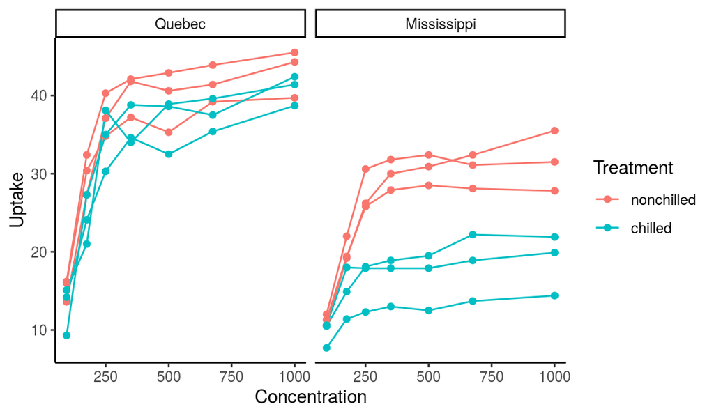

```r
### Demonstration code for making a line plot. LINE PLOTS REQUIRE THE GROUP AESTHETIC (what variable connects the points?) in order to work properly.
ggplot(CO2_tibble, aes(x = conc, y = uptake, group = Plant, color = Treatment)) +
  geom_line() +
  geom_point() +  ## Think: are points helpful in this plot? not help? play around by removing this geom and see what you think
  facet_grid(~Type) +
  labs(x = "Concentration", y = "Uptake")
```

Using the above code as a template/concept for how to make line plots, create a line plot ONLY for CHILLED plants. This will require you to FIRST create a new tibble of only the data of interest, and then plot that data. Be careful: think when plotting, are all the aesthetics specified in the template still needed? Write this code in TWO WAYS:

- First way: create your new tibble to plot and save it to a variable. Then plot from that tibble.
- Second way: create your new tibble to plot but DO NOT save it - instead, directly *pipe it into ggplot*. Remember: The first argument to `ggplot()` is the dataframe/tibble. As an example of how this works conceptually, using iris:

```
## filter: removed 100 rows (67%), 50 rows remaining
```

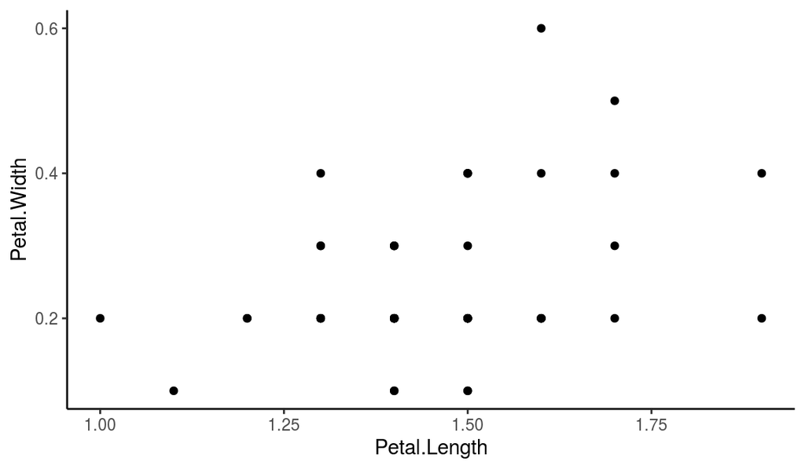

```r
  ## GUIDING EXAMPLE of piping data directly into ggplot (don't modify this code - it is an example template!)
  iris %>%
    filter(Species == "setosa") %>%
    ggplot(aes(x = Petal.Length, y = Petal.Width)) + ### Note: we don't supply the tibble to ggplot since it's being PIPED IN!
    geom_point()
```

```r
### q14 code way 1
#First way: create your new tibble to plot and save it to a variable. Then plot from that tibble.

#creating a new tibble and saved
CO2_tibble %>%
  filter(Treatment == "chilled") -> q14_part_tibble1
```

```
## filter: removed 42 rows (50%), 42 rows remaining
```

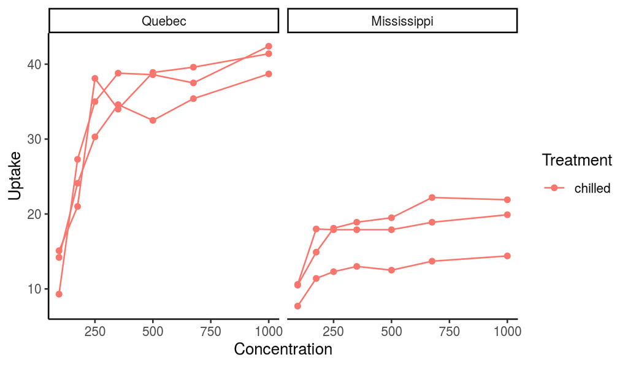

```r
#ggplot + with new tibble
ggplot(q14_part_tibble1,
       aes(x=conc,
           y=uptake,
           group=Plant,
           color=Treatment)) +
  #line graph
  geom_line() +
  #point graph
  geom_point() +
  #seperated for Type
  facet_grid(~Type) +
  #clear up the axis
  labs(x="Concentration" , y="Uptake")
```

```
## filter: removed 42 rows (50%), 42 rows remaining
```

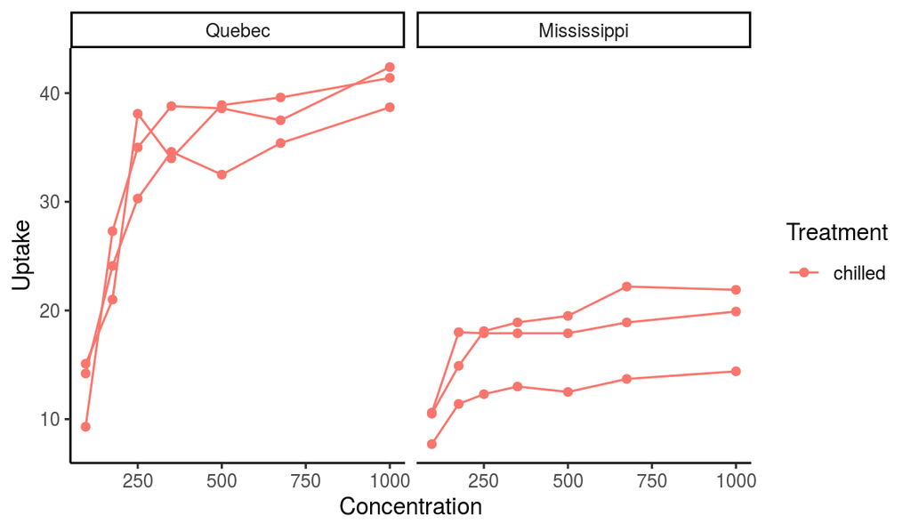

```r
### q14 code way 2
#Second way: create your new tibble to plot but DO NOT save it - instead, directly pipe it into ggplot.

#New tibble but it is NOT SAVED
CO2_tibble %>%
  #tiblle filter
  filter(Treatment == "chilled") %>%
  #pipping the ggplot
  ggplot(aes(x=conc, y=uptake, group=Plant, color=Treatment)) +
  #line graph
  geom_line() +
  #point graph
  geom_point() +
  #separated be type
  facet_grid(~Type) +
  #clear up the axis titles
  labs(x="Concentration", y="Uptake")
```

##### Question 15

Make a boxplot of uptake values for all plants exposed to concentrations of 175 mL/L, where you are *somehow distinguishing* (colors, fills, facets, *choose your adventure!*) between both Treatment (chilled vs nonchilled) and Type (Quebec vs Mississippi). Make sure your figure is well-designed using principles you have learned by reading “Fundamentals of Data Visualization” - do not make an “ugly” or “bad” figure.

```
## mutate: new variable 'uptake_plant' with 2 unique values and 0% NA
```

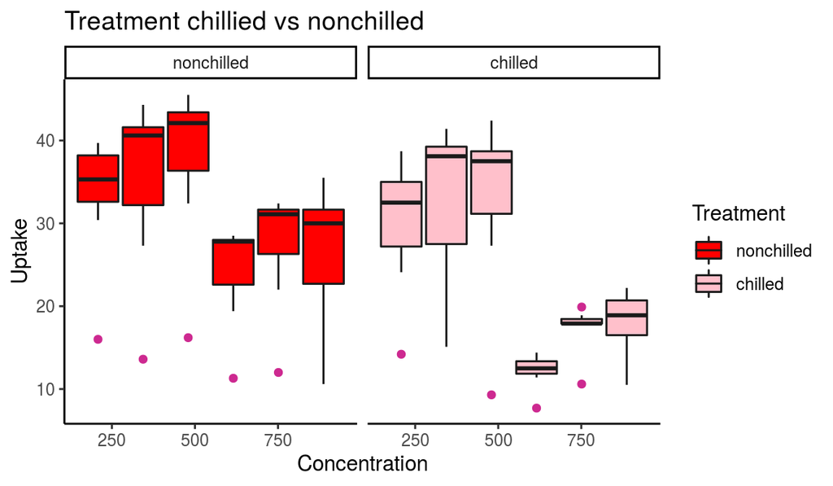

```r
#using the tibble not saving a tibble
CO2_tibble %>%
  #changing the tibble cloumns
  mutate(uptake_plant=(conc >=175)) %>%
  #adding in the gpplot2+ axis + group + fill
  ggplot(aes(x=conc, y=uptake,group=Plant,fill=Treatment))+
  #boxplot graph + outlier color + color of the outer box
  geom_boxplot(outlier.color ="maroon3", color="gray10")+
  #separated by trreatment
  facet_grid(~Treatment)+
  #clearing up the axis title + title
  labs(x="Concentration", y="Uptake", title="Treatment chillied vs nonchilled") +
  #coloring in the box
  scale_fill_manual(values = c("red", "pink"))
```

##### Question 16

Reproduce the figure below *but with colors/fills/theme/ customized to your liking* (just keep labels, faceting, X, and Y axes the same). Do NOT use the same colors/fills, and do NOT use the same theme as me! Again, make sure your figure is well-designed using principles you have learned by reading “Fundamentals of Data Visualization” - do not make an “ugly” or “bad” figure.**Your code should be a single piped command doing both the `dplyr` data manipulation AND the `ggplot2` plotting.**

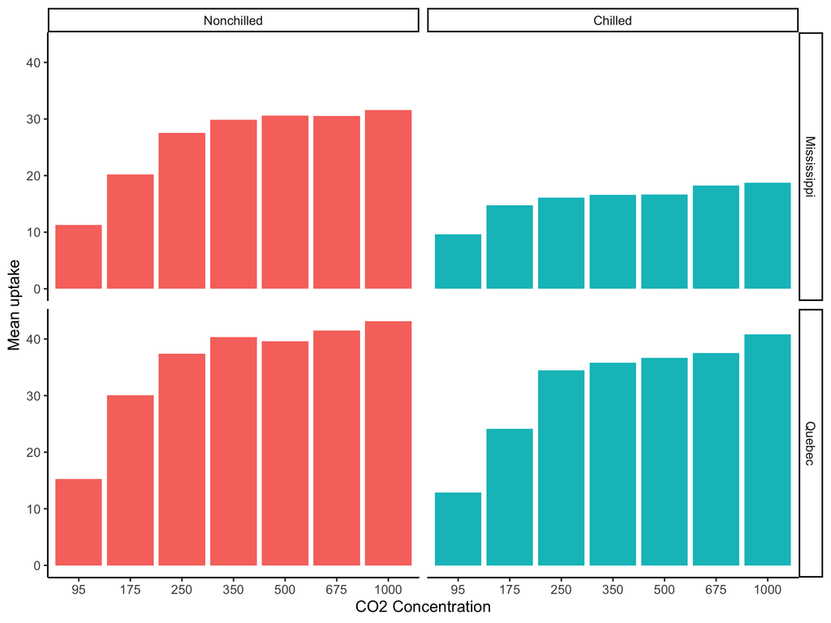

Figure to re-create

The hints you need to accomplish this task:

- Think carefully about what variables are plotted on each axis, and devise BY HAND ON PAPER!!! a strategy for how you can manipulate the tibble to obtain these values.
- By default, `geom_bar()` will automatically do counting under the hood (refer back first couple questions from `More practice with ggplot2`). If we want the bar height to NOT be a count, you need to use this argument `geom_bar(stat="identity")` - this overrides the default `stat="count"` which `geom_bar()` implicitly calls to COUNT the data! You can also use `geom_col()` which is equivalent to `geom_bar(stat="identity")`.
- Look at the X-axis - the columns are evenly spaced to represent CATEGORIES of concentrations. This occurs when you explicitly make the X-axis a factor - even though numbers are there, they will now be treated as categories. You don’t have to redefine a column for this - just specify the variable as `factor(variable)` in your ggplot aesthetic specification rather than just `variable`.
- When modifying tibbles, it is best to do any summaries AFTER all other modifications - summarizing removes columns and rows which you need to use to modify variables.
- NOTE THE ORDER OF THE FACETS! You may have to modify variables to achieve this. Even bigger hint: You can redefine variables as factors and change their levels within a piping chain! Better yet, don’t redefine but create a whole new one so, in case of problems, the original data is still there! For example with iris:

  ```r
  ### Example of making a new factor variable within dplyr piping
  ### The first new column changes the order
  ### The second new column changes the order AND names of levels (labels)
  iris %>%
    mutate(species_factor_custom_levels        = factor(Species, levels=c("virginica", "setosa", "versicolor")), ## change order, preserve labels
                  species_factor_custom_labels = factor(Species, labels=c("Setosa", "Versicolor", "Virginica")), ## preserve order, change labels
                  species_factor_custom_levels_and_labels = factor(Species, levels=c("virginica", "setosa", "versicolor"))  ## change order, change labels
        ) -> iris2
  ## See the different versions of the species factor
  print(levels(iris2$Species))
  ## [1] "setosa"     "versicolor" "virginica"
  print(levels(iris2$species_factor_custom_levels))
  ## [1] "virginica"  "setosa"     "versicolor"
  print(levels(iris2$species_factor_custom_labels))
  ## [1] "Setosa"     "Versicolor" "Virginica"
  print(levels(iris2$species_factor_custom_levels_and_labels))
  ## [1] "virginica"  "setosa"     "versicolor"


  ### OR A MUCH CLEANER APPROACH!!!
  ### Defining beforehand makes it MUCH EASIER to count parentheses!!
  new_levels <-  c("virginica", "setosa", "versicolor")
  new_labels <- c("Virginica", "Setosa", "Versicolor")
  iris %>%
    mutate(species_factor_custom_levels            = factor(Species, levels=new_levels), ## change order, preserve labels
                  species_factor_custom_labels            = factor(Species, labels=new_labels), ## preserve order, change labels
                  species_factor_custom_levels_and_labels = factor(Species, levels=new_levels, labels = new_labels)  ## change order, change labels
          ) -> iris2

  ### If you want, you could also remove the original Species from the tibble
  ### but, can't hurt to keep it around. really your call!
  iris2 %>% select(-Species) -> iris2
  ```

```
## mutate: new variable 'states_levels' with 2 unique values and 0% NA
```

```
## group_by: 3 grouping variables (states_levels, Treatment, conc)
```

```
## summarise: now 28 rows and 4 columns, 2 group variables remaining (states_levels, Treatment)
```

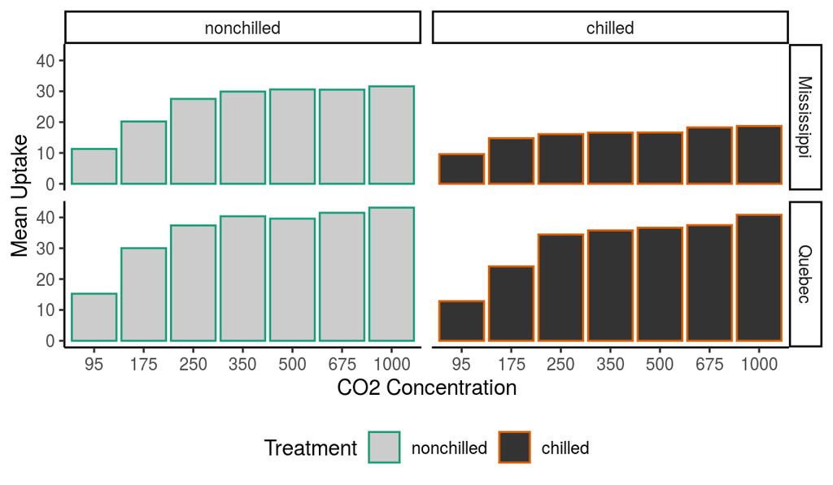

```r
## make your recreated but customized figure here

#I am doing the clearer method because the first method confused me too much
#first make a new levels
new_levels <-  c("Mississippi", "Quebec")
#data set
CO2_tibble%>%
  #mutate + state the levels with a factor + Making the levels into the new levels
  mutate(states_levels = factor(Type, levels=new_levels))%>%
  #group the state levels + treatment and conc
  group_by(states_levels,Treatment,conc) %>%
  #summarise + new column name + mean of the uptake
  summarise(mean_uptake = mean(uptake)) %>%
  #ggplot + aes + x = making conc a factor + y = mean uptake + fill in with treatment
  ggplot(aes(x = factor(conc), y = mean_uptake, fill = Treatment, color=Treatment)) +
  #geom_bar to make a bar plot. The stat identity to fix the spaces
    geom_bar(stat = "identity") +
  #the fancy function to make the 4 barplot
   facet_grid(states_levels~Treatment) +
  #clearing up the labels
  labs(x="CO2 Concentration", y="Mean Uptake") +
  #the outline of the bar colored with the brewer function Dark2
  scale_color_brewer(palette="Dark2")+
  #It will make it a grey scale.
  scale_fill_grey(start=0.8, end=0.2) +
  # its a new theme to put the grid in the graph
  theme_set(theme_bw()) +
  #placing the legend at the bottom
  theme(legend.position="bottom")
```